**Lab 063 · five live code tasks + EXIT**

The preview is read-only. Complete the runnable notebook in Colab or Jupyter; student functions are intentionally blank.

# Lab 063 · Build the prior that teaches TabPFN what a table can be

Lesson · Reference · Sources · Fresh author evidence · Reproduction contract

**Scope: historical numerical generator key parts.** Build the layered sparse SCM/BNN generator, observe nodes, construct multiclass tasks and evaluate a finite posterior. No pretrained checkpoint or new Transformer training is required. The default run creates 12 new worlds per family and 48 small logistic fits (one ordinary and one shuffled probe per world). Original prior-training and benchmark reproduction are INCOMPARABLE / NOT_RUN. PROVIDED cells expose the complete generator/experiment; five TODOs feed that experiment; CHECKs diagnose mechanism errors; EXIT saves your actual kernel identity and explanation. Synthetic data is the subject of this paper component, not a substitute for an unperformed real-data benchmark.

### Running on Google Colab?

Colab opens only this single file, so the course package (`relkit`) and the lab dependencies (xgboost, lightgbm, catboost, …) are **not** present by default. The cell below fixes that: on Colab it shallow-clones the course repo, installs `requirements-labs.txt`, and switches into `labs/` so `relkit` imports and the data cache resolve. **On a local venv or your own Jupyter it does nothing — just run it and continue.**

```python
# @colab-bootstrap — PROVIDED. Makes the lab self-sufficient on Google Colab; a no-op elsewhere.
import os, sys

if "google.colab" in sys.modules:
    if not os.path.isdir("/content/relational"):
        !git clone --depth 1 https://github.com/Avistian/relational.git /content/relational
    %pip install -q -r /content/relational/requirements-labs.txt
    os.chdir("/content/relational/labs")
    print("Colab ready — working dir:", os.getcwd())
else:
    print("Not on Colab — using the local environment as-is.")
```

## The generator defines the problems the model learns to solve

TabPFN v1 made the inference mechanism concrete. Its fixed weights still embody assumptions learned before the real table arrived. This lesson follows those assumptions back to the generator. The crucial connection is between task-level structure and row-level observations: the PFN must infer one sampled world from several rows, not memorize unrelated random labels.

## What does a pretrained predictor expect a table to look like?

> **In plain terms.** Before TabPFN ever meets your data, it was trained on a flood of *made-up* tables. This lesson opens the factory that stamps out those tables. Knowing the factory tells you which patterns the finished model is prepared to recognize — and which it will never have seen.

Start with a fact about real tables. The columns of a database table can depend on one another. A customer's age may affect income. Income may affect a purchasing decision. A recorded account score may be an effect of several hidden causes.

Correlation has more than one source. Two observed columns can correlate because one causes the other. They can also correlate because they share an unobserved cause. They can even correlate because the process that selected the rows coupled them. A useful supervised predictor can exploit those associations without identifying which causal story is true.

**A small selection example.** Let two independent binary variables X and Y each be 1 with probability one half. The four pairs `00,01,10,11` are equally likely. Now keep a row only if at least one variable is 1. The selected table has only `01,10,11`, each with conditional probability one third. Within it, `P(Y=1 | X=0, selected)=1`, while `P(Y=1 | X=1, selected)=1/2`. Selection created an association even though neither variable caused the other. In graph notation, `X → S ← Y` means both determine the selection flag S; conditioning on `S=1` couples them. **Try it:** retain all four pairs again and verify that both conditional probabilities return to one half. The row-selection rule belongs on a prior card alongside the graph.

**Where this sits in the sequence.** Lesson 061 trained a prior-data fitted network, or **PFN**, to predict from a context. A **context** is a set of labeled examples of a new task. Lesson 062 traced a released TabPFN v1 checkpoint through a real prediction. Here we open the other half of that system: the **distribution of synthetic tasks** used to teach such an inference algorithm.

Your tangible outcome is a runnable prior card. You will sample one mechanism. You will generate a table through it. You will inspect what becomes visible, form classes, and diagnose which assumptions change a prediction.

**The primary source.** The reference is [TabPFN v1, arXiv 2207.01848v6](https://arxiv.org/html/2207.01848v6), especially §4, Appendix C, Appendix E.4/Table 5 and the prior ablation in Appendix B.4/Table 4. This lab implements the central numerical **generator** path from [historical `mlp.py`, revision 44f60d8](https://github.com/automl/TabPFN/blob/44f60d83c545238c551f1481a5f6f031bbf376bf/tabpfn/priors/mlp.py), not a newly invented TabPFN predictor.

> **Scope check.** The generator has an architecture, but its weights are sampled to *create data*. They are not the trained Transformer weights used for deployment. Building the data factory is not the same as building the model.

## Two levels of randomness: a world and its observations

> **In plain terms.** There are two dice being rolled. One big roll picks the *rules of a world* — the graph, the coefficients, the noise settings. Many small rolls then generate *rows* inside that one world. Keeping these two levels straight is the single most important idea in the lesson.

**The pieces of a world.** A **structural causal model**, abbreviated SCM, contains variables, directed edges and structural assignments. A **directed edge** from variable i to variable j permits i to enter j's equation. A **directed acyclic graph**, or DAG, has no directed cycle. Because there is no cycle, its variables can be evaluated in an order where every parent is available before its child. A variable's **parents** are its immediate inputs. An **exogenous noise** variable is a source of randomness outside those assignments; independence of these noises is an assumption we choose for the synthetic world.

**What one assignment looks like.** In general, a structural assignment is `Z_j = f_j(Z_parents(j), ε_j)`. The deterministic function f_j and the noise distribution are both part of the world. Noise values ε_j differ between rows. The function, its parameters and the noise distribution stay fixed.

**Worked example.** Suppose `income = 2 × education + ε_income`. Every row uses coefficient 2. Individuals receive different draws of ε_income. Sampling a fresh coefficient for every individual would describe a different learning problem entirely.

**Naming the two levels.** Let φ denote all task-level choices: family, graph, weights, biases, activation, noise parameters, observed nodes and label rule. The sampling hierarchy is `φ ~ p(φ)` first, then many rows `D ~ p(D | φ)`. The PFN training algorithm draws new worlds repeatedly. Within a task, context rows and query rows teach and test the same relationship. They differ only in whether their labels are supplied to the predictor.

### One world per dataset, not per row

The distinction is easy to lose in code. A batch of 32 tasks needs 32 sampled worlds if the task contract specifies independent worlds. It does *not* mean 32 worlds per row. The released `new_mlp_per_example` flag chooses whether separate batch items share the sampled MLP, and the historical checkpoint records `True`. Our operator samples one new world per dataset, then vectorizes its equations over all rows.

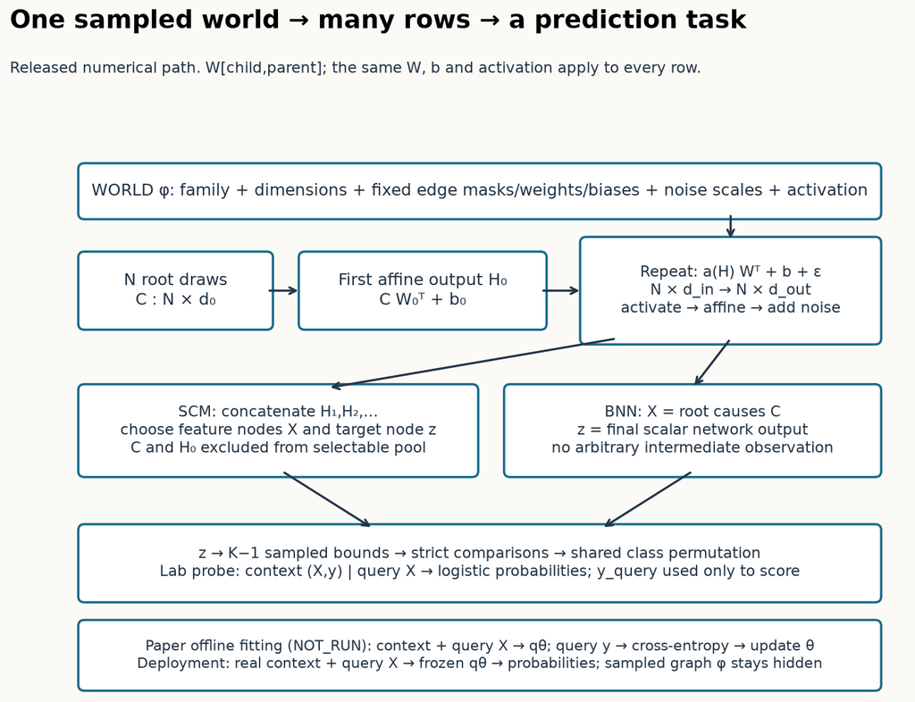

Trace the released generator: shared world parameters, row-level noise, intermediate node selection, joint class construction, and the context/query information boundary. Full-size figure.

**Connecting the ideas.** The released generator produces a shared computation for a whole task. Sparsity changes that computation’s graph before observations are drawn, so it changes which relationships all the task’s rows can reveal.

### The synthetic prior: sample a world, then sample its rows

**Trace before reading:** If you resample the graph for every row, are you sampling the same kind of task?

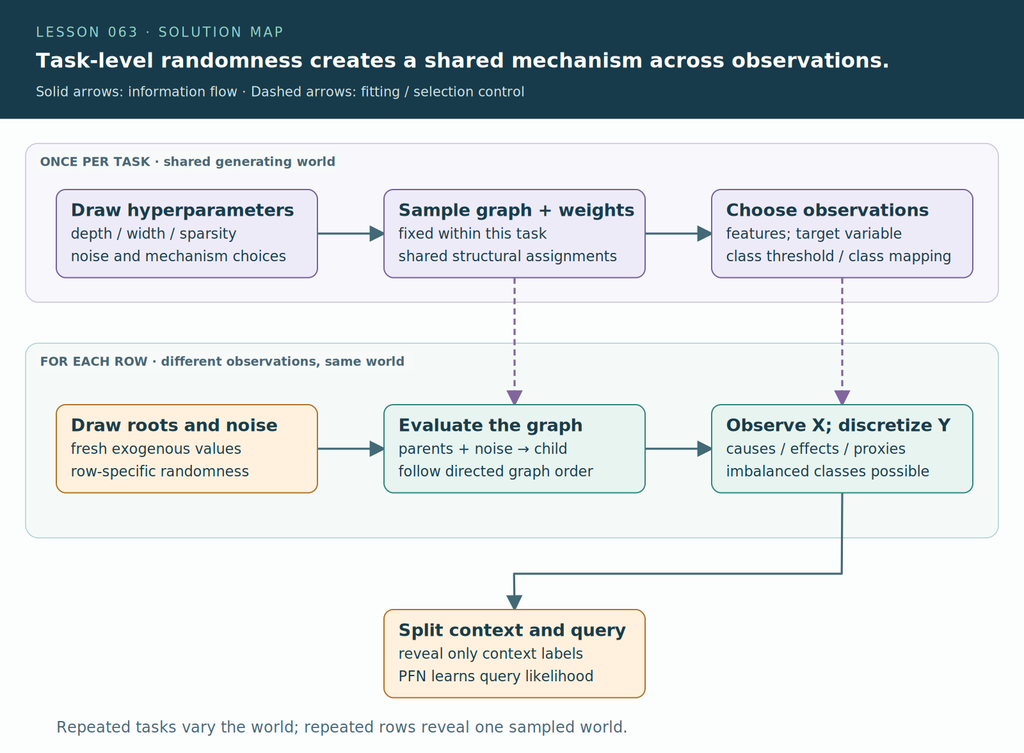

**How the parts work together:** No. A task has shared graph, weights and observation choices; rows receive fresh root/noise draws under that shared world. Resampling the mechanism per row destroys the within-task relationship the PFN is trained to infer.

**Pictured scope:** Released SCM-style generator concept and lesson reconstruction. Visible variables need not be causal parents of the target; predictive inference is not causal identification.

Full-size vector diagram. Scroll on narrow screens to keep labels legible.

**Text route: components and connections**

1. **Draw hyperparameters**: depth / width / sparsity; noise and mechanism choices. Connects to Sample graph + weights.
2. **Sample graph + weights**: fixed within this task; shared structural assignments. Connects to Choose observations; Evaluate the graph (fitting/selection control).
3. **Choose observations**: features; target variable; class threshold / class mapping. Connects to Observe X; discretize Y (fitting/selection control).
4. **Draw roots and noise**: fresh exogenous values; row-specific randomness. Connects to Evaluate the graph.
5. **Evaluate the graph**: parents + noise → child; follow directed graph order. Connects to Observe X; discretize Y.
6. **Observe X; discretize Y**: causes / effects / proxies; imbalanced classes possible. Connects to Split context and query.
7. **Split context and query**: reveal only context labels; PFN learns query likelihood.

## The released generator: follow the computation all the way through

> **In plain terms.** The generator is a small neural network run *backwards from its purpose*: instead of learning weights to fit data, it fixes random weights and pushes noise through them to *manufacture* data. We now trace that push one layer at a time.

**The construction.** Appendix C.1 constructs a tractable subfamily of DAGs by starting with a layered MLP and deleting edges. A **multilayer perceptron**, or MLP, is a sequence of affine maps and elementwise nonlinearities. Here each scalar neuron is a graph variable. Connections occur between consecutive layers, so acyclicity is built into the representation. This construction covers many DAGs but not every conceivable DAG with every possible function.

**Reading the shapes.** For a layer with `d_in` parents and `d_out` children, the released weight matrix W has shape `d_out × d_in`: **child first, parent second**. For N rows, the parent matrix has shape `N × d_in`. Multiplying by `W.T` gives one weighted sum for every row and child. A bias b, shape `d_out`, shifts that sum. Broadcasting adds the same bias to all rows. The noise matrix ε, shape `N × d_out`, supplies a distinct noise value per row and child.

**The exact historical path**, step by step:

1. Draw root causes C and compute `H0 = C @ W0.T + b0`. This first affine layer has no explicit activation or added GaussianNoise module.
2. For later layers, compute `Hl = a(H(l−1)) @ Wl.T + bl + εl`. Activation is applied to parent values **before** this affine map; structural noise is added **after** it.
3. In the SCM branch, concatenate `H1, H2, …` into a pool of selectable variables. The raw root causes and first affine output H0 are excluded from this pool in the released code.
4. Select observed feature columns X and a scalar continuous target z. Convert z into class labels, then supply labeled context and unlabeled queries to the downstream learner.

> **Scope check — paper versus executable source.** Appendix C.1 writes an abbreviated node equation with activation outside the weighted sum and noise. The historical `generate_module` instead builds `Activation → Linear → GaussianNoise`. These are not numerically interchangeable. This lesson's diagram, worked example, notebook and source checks follow the released order. The general SCM definition accommodates either order; a fidelity claim still has to choose one.

**Worked example — three affine layers, identity activation.** Take `C=(1,−2)`, `W0=diag(2,1)`, `b0=(0,1)`, giving `H0=(2,−1)`. Next use `W1=(1,−1)`, `b1=.5`, `ε1=.1`: `H1=2−(−1)+.5+.1=3.6`. Finally `W2=(2)`, `b2=−.2`, `ε2=.3` gives `H2=2×3.6−.2+.3=7.3`. Now switch the activation to tanh. The second value becomes `tanh(2)−tanh(−1)+.6≈2.3256`; it does *not* become `tanh(3.6)`, because activation acts on the *parents* before the affine map.

**How this is validated.** The lab checks this recurrence against the actual historical MLP class, using its sampled weights and recorded causes/noises. Sixteen cases span SCM/BNN, independent/block sparsity and Identity/Tanh/LeakyReLU/ELU.

> **Scope check.** The maximum absolute discrepancy is about `5.09×10⁻⁶` between the original float32 path and NumPy float64 evaluation. That checks conditional computation. It does not establish identical random streams, complete task distributions, or training trajectories.

## Sparsity is a task-level graph sample

> **In plain terms.** "Sparsity" here means deleting edges *once per world* to decide which variables are even connected. It is a choice about the shape of the world, not a training trick that changes every step.

**Why deleting an edge matters.** An edge has a coefficient. Setting that coefficient to zero removes its contribution from every row of the task. This is a **task-level graph sample**. It differs from ordinary neural-network dropout, which redraws masks during training to regularize a fixed predictive model.

### Independent-edge sparsity

Independent sparsification samples a binary keep mask with probability `1−p` per edge. The released checkpoint selects the square-root scaling flag. Its Bernoulli initializer uses the unusual divisor **`1−√p`**, not `√(1−p)`.

**Worked example.** For p=.25, raw weights `(1,2)` and mask `(1,0)` become `(2,0)`. We preserve that expression because changing it would change the released operator. The first affine matrix skips independent dropout and this correction.

### Blockwise sparsity

Blockwise sparsification uses a different rule. Divide a matrix into floor-sized diagonal blocks. Keep those blocks. Leave other entries and any leftover rows/columns zero. Divide kept raw weights by `√keep_fraction`.

**Worked example.** For a 4×4 matrix with two 2×2 blocks, half the entries remain and their scale factor is √2. This branch also acts on the first affine matrix. It can create strongly interacting groups with few paths between groups. Neither rule guarantees that each selected feature predicts the selected target.

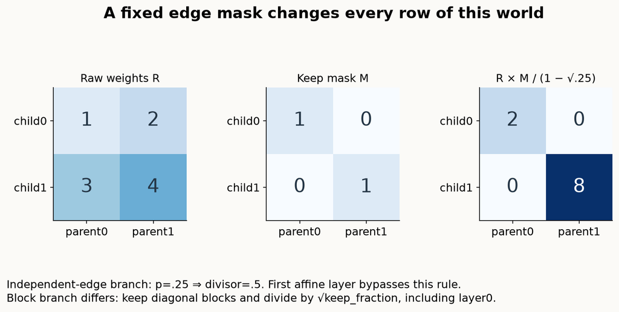

Fixed independent-edge fixture: raw matrix times binary mask divided by 1−sqrt(.25); contrast the separately explained blockwise rule. Full-size figure.

**Connecting the ideas.** A sampled graph contains more variables than the final table reveals. Choosing observed columns can hide causes, expose effects or retain proxies. The resulting predictive table therefore does not automatically identify the causal graph that generated it.

### Why prefer smaller, sparser worlds?

The paper's **simplicity prior** favors mechanisms with fewer nodes and parameters. This implements one particular meaning of Occam's razor. It is an inductive assumption, not a proof that a smaller graph generated your database.

> **Scope check.** A deep nonlinear graph can generate a simple observed problem. A small hidden-variable graph can generate a difficult one. Count parameters and inspect the observation rule before equating generator size with prediction difficulty.

## Hyperparameters are themselves random variables

> **In plain terms.** In an ordinary project, a hyperparameter is a knob *you* tune on *your* dataset. Here every knob is itself sampled, because the goal is to describe a whole *distribution of tasks*, not to fit one.

**What a hyperparameter controls here.** The paper mixes a BNN generator and an SCM generator with equal probability. Inside each family it varies graph depth, width, activation, sparsity, noise and observation choices. A hyperparameter here controls a **distribution of tasks**. It is not a setting fitted separately by cross-validation on the deployment table.

**How positive quantities are sampled.** Table 5's shorthand TNLU samples positive values in stages: draw distribution parameters on a logarithmic scale, sample a positive truncated normal value, optionally round, then add a minimum. A logarithmic scale gives comparable probability to multiplicative ranges such as .01–.1 and .1–1. Truncation prevents negative scales or sizes.

> **Scope check — the sampler is not exactly Table 5.** The historical implementation's `meta_trunc_norm_log_scaled` draws a mean μ and a coefficient of variation r, then sets standard deviation `σ=μr`. Its r range defaults to .01–1. Table 5 describes independently log-uniform μ and σ. Those descriptions are not the same distribution.

**The full set of ranges and our deliberate deviations.** Each row below pairs the paper/checkpoint range with the choice this numerical lab makes.

| Quantity | Paper Table 5 / checkpoint range | Numerical lab choice |
| --- | --- | --- |
| Layer count | Mean range 1–6; round; add 2 | Released relative-σ sampler; cap total affine hidden layers at 5 |
| Hidden width | Mean range 5–130; round; add 4 | Same sampler; cap at 32; SCM also requires at least `1+2F` nodes |
| Root-cause count | Mean range 1–12; round; add 1 | Same sampler; cap at 16; BNN roots are its F input features |
| Weight standard deviation | Mean range .01–10 | Sampled, without an extra lab scale cap |
| Noise standard deviation | Mean range .0001–.3 | Sampled; optionally draw node-specific positive scales |
| Edge dropout | `.9 × Beta(a,b)`, with a,b uniform .1–5 | Same hierarchy; sampled once per world |
| Activation | Tanh, LeakyReLU, ELU, Identity | Uniform choice among these four named paper functions |
| Root sampling | Released checkpoint selects mixed distributions | Conditional Gaussian root branch only |

> **Scope check.** These architecture caps change the distribution; they do not merely make an identical experiment faster. The manifest records raw and capped sizes. Gaussian root means/scales can be shared across rows, but we do not execute the released mixed Gaussian/categorical/Zipf root branch. We also omit input-feature scaling, categorical conversion, missingness corruption, full `FlexibleCategorical` preprocessing and its class-compatibility rejection. The pinned repository's default `model_configs.py` has further differences from the actual checkpoint, so it is source context, not a certificate of the final training recipe. The source inventory separates its identity from selected checkpoint metadata.

## Observed features can be causes, effects, or proxies

> **In plain terms.** The learner never sees the whole world. It sees a few nodes someone chose to reveal. Those revealed columns might be *causes* of the label, *effects* of it, or mere *shadows* of a hidden cause — and the model cannot tell which.

**Two families, two habits.** In a BNN task, sampled roots are inputs X and the last network output is the target. This favors an input-to-output perspective. In an SCM task, feature and target nodes can be selected from intermediate layers. A feature might be an ancestor of y, a descendant, or a variable connected through an unobserved common cause. The unselected nodes remain latent: present in the generator, absent from the table.

**Worked example.** Consider `U → X1`, `U → Y`, and `Y → X2`. Here U is a hidden common cause and X1 is a proxy for it. X2 is an effect of Y. Observing `(X1,X2)` can make Y predictable without observing U. Replacing X2 with an unrelated variable removes information without changing the latent graph.

**What that prediction is, and is not.** A predictor that exploits X2 has learned an association. It has not learned what would happen if an intervention set Y to a new value in a real system.

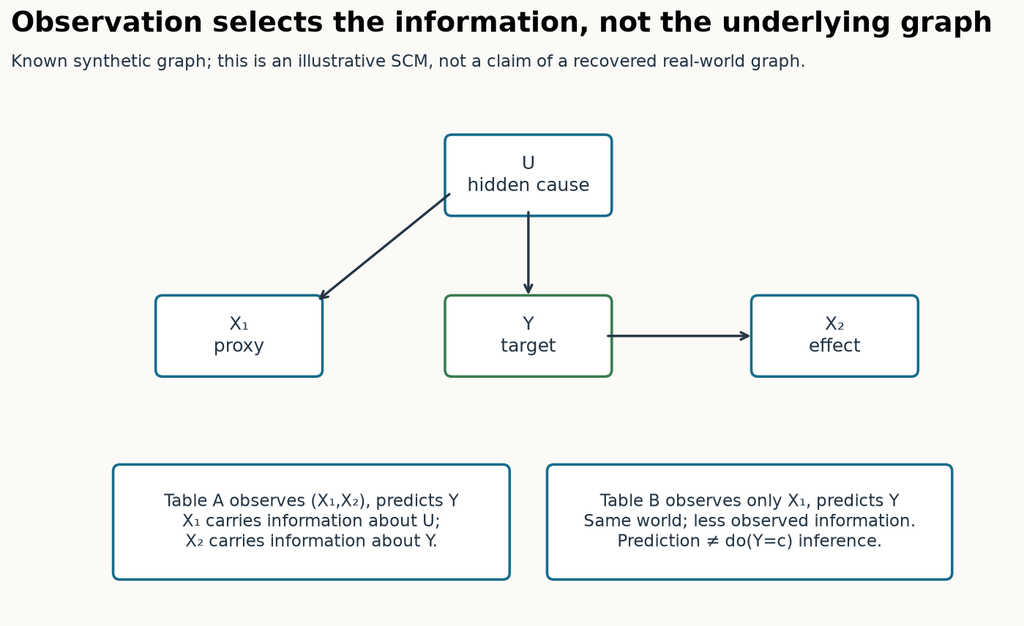

Illustrative observed/hidden-node graph: a proxy and an effect can carry predictive information without identifying intervention effects. Full-size figure.

**Connecting the ideas.** The structural computation yields a continuous target mechanism. Converting it to classes changes boundaries and class balance, connecting the generator to the classification likelihood the PFN actually optimizes.

### The exact selection rule, and one intentional departure

Released node selection has details worth tracing. In the non-block selection branch, `randperm(pool_size−1)` excludes the last coordinate. When `y_is_effect=True`, the final coordinate is selected separately as the target. Blockwise feature sampling chooses a contiguous window, then shuffles its indices; optional sorting restores feature order. With the last-node target option, that block can include the target among features.

> **Scope check.** Our lab rejects and redraws such overlapping selections, records the rejection count, and checks that features are distinct. This is an intentional departure from a possible historical label leak, not source parity for that corner case.

### Why this is still not a relational prior

For the relational mission, these are still single-row variable graphs. A customer entity connected to many transactions is not represented merely by drawing a larger MLP. A relational prior would have to specify entities, relation structure, aggregation and event/label clocks. A realistic-looking covariance matrix in a flattened table does not demonstrate that those mechanisms are modeled.

## How a continuous mechanism becomes an imbalanced multiclass task

> **In plain terms.** The generator first produces a single real number per row. To make class labels, it slices that number line at random cut points and then *renames* the slices. The cut points determine class counts and can create imbalance. Renaming removes the ordering of class IDs without changing those counts.

**The rule.** The generator first supplies a real-valued target z. Section 4.5 samples K−1 target values as class bounds and counts how many bounds each target strictly exceeds: `r_i = Σ_j 1[z_i > B_j]`. It may then permute class identities. Integer labels are names; a class labeled 2 need not be semantically between classes 1 and 3.

**Worked example.** For targets `(-1,−.1,.2,.5,1)`, choose bounds `(-.1,.5)`. The ranks are `(0,0,1,1,2)`: equality belongs to the lower interval because the comparison is strict. Relabel ranks through permutation `(2,0,1)` and the observed labels become `(2,2,0,0,1)`. A mean or median threshold cannot reproduce this multiclass rule.

**Check the counts.** Before relabeling, the counts are `(2,2,1)`; afterward they are `(2,1,2)`. The smallest class still has one row. Change the first bound from −.1 to .2 while holding the targets fixed: strict-threshold counts become `(3,1,1)`. Moving a bound changes class balance; renaming the classes does not. Trace both operations separately in your prior card.

**Two consequences to expect.** Sampling bounds with replacement can repeat a value, making an interval empty. Repeated targets can also create ties. Do not force every class to appear merely because K was sampled.

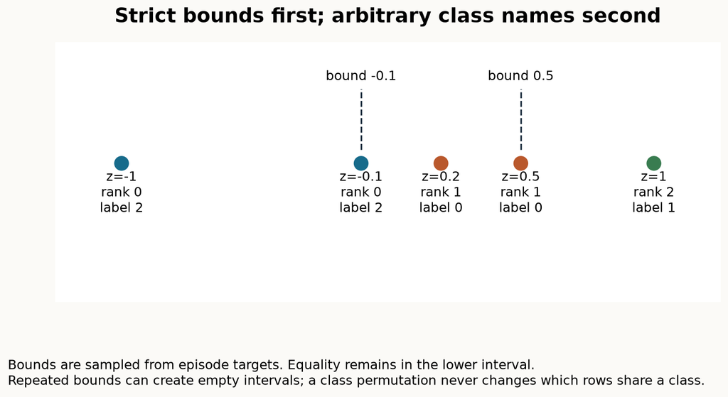

Strict bound comparisons on one coherent five-row example, followed by shared arbitrary class renaming. Full-size figure.

**Connecting the ideas.** If both features and labels depend on the sampled world, a query’s features can carry information about that world. This probabilistic observation is distinct from whether a particular released architecture lets query rows influence one another.

### The class-count sampler and what the lab keeps

The source class-count sampler chooses binary half the time; otherwise it rounds a uniform draw from 2 to the maximum class count. Thus the remainder is not exactly uniform over integers: the endpoint bins are narrower. The lab retains that rule with maximum 10, samples bounds from the whole synthetic episode and applies one class permutation to every row. It does not force balanced classes.

> **Scope check.** The full historical wrapper additionally tries to repair context/query class support, remaps valid class IDs contiguously and applies a random label shift. The lab reproduces the inner rank operator and shared relabeling, not those later wrapper steps. Using full-episode targets for bound construction is a declared **joint task generator**, as in the paper; it is not a recipe for choosing real test-label thresholds. Likewise, fitting preprocessing on synthetic episode rows in the original wrapper must not be copied uncritically into real deployment evaluation. Here the diagnostic probe fits its scaler and coefficients only on context rows. The fixed synthetic label rule is defined before the learner receives context/query roles.

## The query's features can also update beliefs about the world

> **In plain terms.** You might think only the *labeled* rows tell you which world you are in. But because the generator models the feature distribution too, even an *unlabeled* query row's features are a clue about which world produced this table.

**The quantity we want.** A posterior predictive distribution, or **PPD**, averages predictions over worlds weighted by how plausible those worlds remain after observing data. Let D be labeled context, x* a query feature vector and y* its unknown label. In a joint generative SCM:

`p(y* | x*, D) = ∫ p(y* | x*, φ) p(φ | x*, D) dφ`.

**Why the query's features enter.** Bayes' rule gives `p(φ | x*, D) ∝ p(φ) p(D | φ) p(x* | φ)` when rows are conditionally independent given φ. The last term, `p(x* | φ)`, shifts the posterior: a query's features can favor one world over another even before its label is known. The familiar simplification using only `p(φ | D)` is justified when the feature distribution contributes the same factor across hypotheses, or when the prior is explicitly conditional on fixed inputs. A general SCM models X as well as Y, so that simplification is not automatic. Joint synthetic label construction can require an even more explicit episode-level likelihood; the independent-row factorization below belongs to the stated finite oracle.

**Worked example — two candidate worlds.** Prior weights are `(.5,.5)`. Context likelihoods are `(.4,.6)`. Query-feature likelihoods are `(.2,.8)`. Their unnormalized posterior masses are `(.04,.24)`. Divide by the total .28 to obtain `(1/7,6/7)`. If the class-1 probabilities in those worlds are `(.1,.9)`, the PPD is `11/14≈.7857`. Ignoring query-feature evidence gives context-only weights `(.4,.6)` and prediction .58. The difference is inference about a **distribution of worlds**, not selecting a single causal graph.

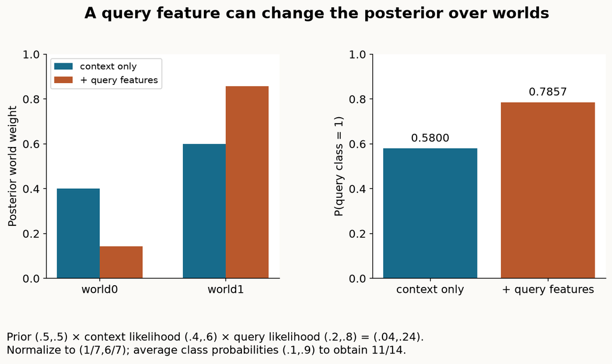

Two-world exact arithmetic: query-feature likelihood changes posterior weights and the class probability from .58 to 11/14. Full-size figure.

### Doing this arithmetic safely

The notebook implements this finite sum in log space. Add log prior, log context likelihood and log query-feature likelihood; subtract `logsumexp` before exponentiating. This prevents underflow when many small probabilities are multiplied. If all worlds assign zero probability to an observation, the posterior is undefined: raising an error is more informative than quietly emitting NaNs.

> **Scope check.** An exact finite-mixture oracle is affordable because it enumerates two worlds. The full TabPFN prior integrates over architectures, weights, noise and observation rules, making that enumeration intractable. A PFN learns to approximate the conditional prediction by minimizing held-out synthetic cross-entropy. At the population optimum, expected cross-entropy is the entropy of the true conditional distribution plus a nonnegative KL divergence from it to the model prediction. This explains the target of prior fitting; finite training, model capacity, optimization and prior mismatch still create approximation error.

## Controlled measurements: what was actually learned or verified?

> **In plain terms.** We now run small, honest experiments on generated worlds to check two things: that generated tables really do carry usable feature–label information, and that a query's features really do shift an exact posterior.

**Predict first.** If a context helps because its features and labels reveal a shared world, what should happen when we permute only its labels? Must every finite task's score get worse? Separately, if two worlds predict different feature distributions, should discarding x* improve the exact oracle's expected log loss?

### The synthetic-probe panel

The fresh author panel contains 12 SCM worlds and 12 BNN worlds. Each has 256 rows, with the first 128 as context, and three observed features. A fixed logistic classifier with C=1 and context-fitted standard scaling predicts the other 128 rows. Its shuffled arm changes only the association between context features and labels; it preserves class counts, features, split, fitted-model recipe and query targets. Missing context classes receive clipped probability `10⁻¹²` and probabilities are renormalized; single-class contexts use a constant predictor. We retain those difficult cases instead of silently filtering them away.

**Reading the metric.** The metric is **negative log likelihood**, equivalently multiclass log loss, measured in nats: smaller is better. A confident wrong prediction incurs a large penalty. Each plotted gap is shuffled loss minus ordinary loss on the same task. The unit of variation is a newly sampled synthetic world.

> **Scope check.** The same integer seed across SCM and BNN is not a matched latent world: their random draws and observation pathways differ. These two family means must not be read as a causal comparison of prior quality.

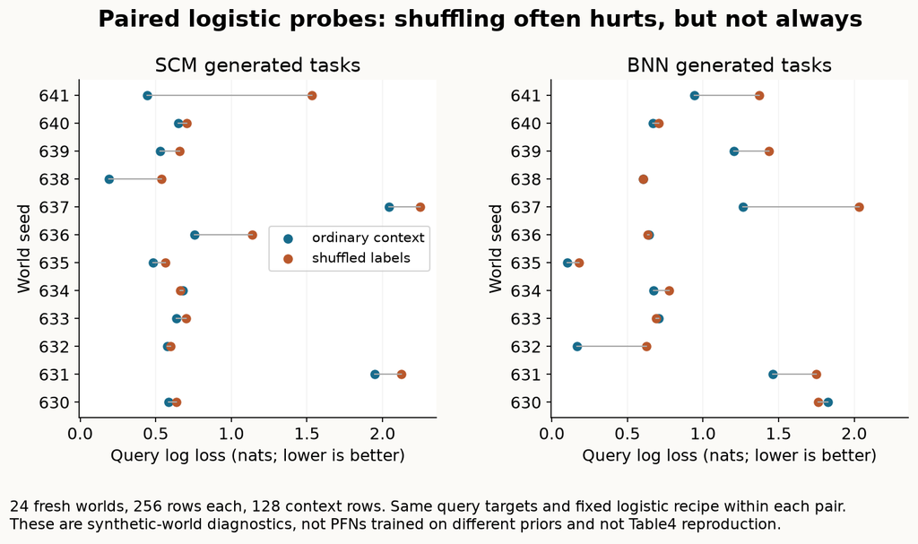

Fresh author reference: paired ordinary/shuffled-context logistic losses on 12 sampled worlds per family. Individual task gaps remain visible; this is not the paper prior-training ablation. Full-size figure.

**The measured numbers.** On this panel, SCM mean loss is .7934 versus 1.0083 after shuffling; the paired gap is .2150 with sample standard deviation .3013 across worlds. Eleven of twelve gaps are positive. BNN mean loss is .8551 versus 1.0468; gap .1917 with standard deviation .2518, positive on eight of twelve worlds. These exceptions occur because permutation can accidentally improve a weak finite-data logistic fit.

> **Scope check.** These probes show learnable feature-label information in many generated tasks. They do not train or evaluate a PFN, and do not rank SCM-trained versus BNN-trained TabPFNs.

### The exact two-world oracle

A separate exact oracle experiment samples 500 tasks from a fully specified two-world distribution: equal world probabilities; `X | φ ~ Normal(2φ−1,1)`; `Y | φ ~ Bernoulli(.1+.8φ)`; X and Y independent conditional on φ. Each task has two labeled context observations and one query. Correct joint prediction gives mean loss .3449; dropping query-feature likelihood gives .3656.

> **Scope check.** The difference is measured on a finite sample; the general expected-loss justification comes from proper probabilistic prediction, not from this one observed sign. The saved artifact includes every context, query, hidden world and posterior weight, so you can reconstruct the calculation independently.

## Intervene on a known generator, then state the limit

> **In plain terms.** Because *we* built the world, we can reach in, switch off one edge, and compute the exact effect. That is a luxury of a known simulator. It is not the same as discovering a cause from data you did not generate.

**The intervention.** For each sampled world we set its largest-magnitude final-layer coefficient to zero while holding root draws, every structural-noise draw, biases and other coefficients fixed. Every earlier layer remains exactly unchanged. If the selected coefficient was already zero, the record explicitly calls this a no-op control. The affected continuous child's change has an exact oracle: `ΔH_child = −a(H_parent) × removed_weight`, because no later operation follows that final affine/noise update.

**Naming what kind of intervention this is.** This is an **edge-mechanism intervention** in a known synthetic world. It is different from a node intervention `do(Z_j=c)`, which replaces the entire assignment of Z_j. It is also different from conditioning on observed `Z_j=c`. Our final-layer child need not be the selected target; the record names the changed latent node and does not claim every intervention changes observed labels.

> **Scope check.** Structural noise enters an assignment and can propagate to later variables. Measurement noise added to an observed feature after generating the world changes the recorded feature without retroactively changing the latent target. The lab separately removes structural noise while retaining the same causes and weights; that is a diagnostic counterfactual, not an observational estimate of irreducible error. Removing noise can affect both features and target when both are graph nodes, so one cannot infer a change in prediction accuracy from its magnitude alone.

## What the paper ablation establishes—and what remains to reproduce

> **In plain terms.** The paper ran its own comparison of priors. Our synthetic probes are *not* that comparison. This section states exactly what the paper showed and exactly what we have not rerun.

**What the paper reports.** Appendix B.4/Table 4 compares **PFNs trained under different priors**, using less compute than the final released model. Reported mean cross-entropies are .811 for BNN, .771 for SCM and .776 for the mixture. Mean ROC AUCs are .865, .881 and .883. The main contrast supports the benefit of the SCM prior over the BNN prior in that experiment. The mixture does not clearly improve on SCM alone across those two metrics. Do not attach the paper's uncertainty notation to our synthetic-world variation or interpret the two metrics as a universal ranking.

> **Scope check — honesty ledger.** Our result is `INCOMPARABLE` to that table: different learner, tasks, observation distribution, budgets and metrics aggregation. The original final training used 18,000 updates × 512 datasets = 9,216,000 synthetic datasets, each of size 1,024, and the paper reports 20 hours on eight RTX 2080 Ti GPUs. Full prior fitting, matched PFN prior ablation and the original real-data benchmark are `NOT_RUN` here. The lab/closer presets are executable generator audits, not paper reproduction presets.

**The route to a real reproduction.** The reproduction contract supplies a larger 64-world-per-family local audit and a concrete route to the historical `PriorFittingCustomPrior.ipynb` and `train.py`. A credible Table 4 reproduction must hold predictor architecture, optimizer, task count, evaluation datasets and selection fixed while varying only prior family, then repeat independent training seeds. Original data splits, preprocessing, meta-validation choices and comparison uncertainty must also be reconciled. Raising the number of synthetic logistic probes is useful evidence about this generator, but it cannot substitute for that experiment.

## Exit: defend a runnable prior card

Submit the five live CHECKs, source-parity result, a freshly measured probe panel, the two-world posterior calculation, one intervention trace, and `student-l063-exit.json`. Your written card must name what is sampled once per world versus once per row, the exact affine/activation/noise order, observed and hidden nodes, class bounds and class renaming, two intentional distribution deviations, and one deployment mismatch that a controlled test could falsify.

**Explain without looking.** Explain why the learned predictor does not return a causal graph or an intervention effect. Compare the three generators you now know: the lesson 061 GP couples function values through a covariance kernel; the BNN samples a feed-forward input-to-target function; the SCM samples a joint variable graph and then decides which variables are visible. The row-token Transformer is the inference network trained on such tasks, not a fourth synonym for the prior.

**A falsifiable next step.** Propose a relational dependency absent from this row generator, specify how to add it, then freeze a real evaluation protocol before observing results. Bring the code trace and a failed case to the teacher. Tomorrow, reconstruct the `(.04,.24) → (1/7,6/7)` posterior and the strict-bound multiclass example from memory before reopening the reference.

## Start the live implementation

Every function below is defined in this kernel. The experiment calls those names directly. Imported original source is used only as a checker. Read the complete path before running: hyperparameters → world → episode → learner → score. The source-parity test holds weights and noise fixed. It does not replace your functions with the author's generator.

```python
# PROVIDED — imports and local artifact root
import base64,copy,functools,hashlib,inspect,json,platform,sys,time,types,zlib
from pathlib import Path
import numpy as np
import pandas as pd
import scipy,sklearn
from scipy.special import logsumexp
from scipy.stats import truncnorm,norm
from sklearn.linear_model import LogisticRegression
from sklearn.pipeline import make_pipeline
from sklearn.preprocessing import StandardScaler
from sklearn.metrics import log_loss
from threadpoolctl import threadpool_limits
from IPython.display import display
for d in [Path.cwd(),Path.cwd()/'labs',Path.cwd().parent]:
    if (d/'relkit').is_dir():ROOT=d.resolve();sys.path.insert(0,str(ROOT));break
else:raise RuntimeError('Run the bootstrap or start inside the course repository')
output=ROOT/'data/cache/l063-v2';output.mkdir(parents=True,exist_ok=True)
VERSIONS={'python':platform.python_version(),'numpy':np.__version__,'scipy':scipy.__version__,'sklearn':sklearn.__version__}
print('CPU generator lab; no model checkpoint download or cloud run')
```

### PROVIDED · Activation and blockwise sparsity

Elementwise activation acts on parent coordinates before the next affine map. ELU has slope 1 on the positive side and exp(x)−1 below 0; LeakyReLU uses slope .01 below 0. block_weights keeps floor-sized diagonal blocks. Leftover coordinates remain zero, matching the historical branch.

```python
# PROVIDED — activation_value
def activation_value(x, activation):
    if activation=='tanh':return np.tanh(x)
    if activation=='identity':return x
    if activation=='leaky_relu':return np.where(x>=0,x,.01*x)
    if activation=='elu':return np.expm1(np.minimum(x,0))+np.maximum(x,0)
    raise ValueError('Unknown activation')
```

```python
# PROVIDED — block_weights
def block_weights(raw,n_blocks):
    """Released block dropout: floor-sized diagonal blocks; leftover coordinates stay zero."""
    raw=np.asarray(raw,float);h,w=raw.shape
    if not 1<=n_blocks<=min(h,w):raise ValueError('Invalid block count')
    bh,bw=h//n_blocks,w//n_blocks;mask=np.zeros_like(raw)
    for b in range(n_blocks):mask[b*bh:(b+1)*bh,b*bw:(b+1)*bw]=1
    keep=n_blocks*bh*bw/raw.size
    return raw*mask/np.sqrt(keep)
```

## TODO 1 · Sample edges that stay fixed across rows

**Goal.** Return a sparse weight matrix for the released independent-edge branch. raw includes init_std; mask is binary. Preserve the source scaling and special first-layer behavior. Reject invalid shapes/probabilities.

**Why it matters.** An ordinary dropout rescaling silently changes the prior, even if the graph picture looks identical.

**Hint boundary.** Separate first=True before the sparsification expression. Read the source denominator carefully; the block operator is separately provided.

```python
# TODO 1 — sparse_weights
def sparse_weights(raw, mask, dropout, first=False):
    raise NotImplementedError("Implement the stated operation")
```

```python
# CHECK 1 — sparse_weights
a=np.array([[1.,2.],[3.,4.]]);m=np.array([[1,0],[0,1]])
np.testing.assert_allclose(sparse_weights(a,m,.25),[[2,0],[0,8]])
np.testing.assert_array_equal(sparse_weights(a,m,.25,first=True),a)
try:sparse_weights(a,m,1.)
except ValueError:pass
else:raise AssertionError('Dropout1 must fail')
print("PASS: sparse_weights")
```

## TODO 2 · Execute a sampled world

**Goal.** Return a list of all layer outputs. Implement the first affine step and then repeated activation→affine→noise using fixed matrices/noise arrays. Validate shapes and reject nonfinite generated values.

**Why it matters.** Both where noise enters and which values feed the next layer define the generated distribution. A correct output shape does not establish correctness.

**Hint boundary.** activation_value is provided. Matrix axes are child,parent. Vectorize across rows; keep graph layers sequential.

```python
# TODO 2 — propagate
def propagate(causes, weights, biases, noises, activation):
    raise NotImplementedError("Implement the stated operation")
```

```python
# CHECK 2 — propagate
c=np.array([[1.,-2.]])
w=[np.array([[2.,0.],[0.,1.]]),np.array([[1.,-1.]]),np.array([[2.]])]
b=[np.array([0.,1.]),np.array([.5]),np.array([-.2])];e=[np.array([[.1]]),np.array([[.3]])]
h=propagate(c,w,b,e,'identity')
np.testing.assert_allclose(h[0],[[2.,-1.]])
np.testing.assert_allclose(h[1],[[3.6]])
np.testing.assert_allclose(h[2],[[7.3]])
# Activation-before-affine is distinguishable from activation-after-affine.
t=propagate(c,w,b,e,'tanh')
np.testing.assert_allclose(t[1],[[np.tanh(2)-np.tanh(-1)+.6]])
try:propagate(c,w,b,[np.zeros((2,1)),e[1]],'tanh')
except ValueError:pass
else:raise AssertionError('One noise per row/node required')
print("PASS: propagate")
```

## TODO 3 · Choose what the learner can observe

**Goal.** Return feature matrix and continuous target from the selectable node pool. Preserve requested column order. Reject duplicate, out-of-range or target-overlapping feature indices.

**Why it matters.** An observed target copy creates a trivial label leak; hidden versus observed roles are central to SCM task diversity.

**Hint boundary.** The caller constructs the correct selectable pool. This function enforces its observation contract, not graph discovery.

```python
# TODO 3 — select_nodes
def select_nodes(values, feature_nodes, target_node):
    raise NotImplementedError("Implement the stated operation")
```

```python
# CHECK 3 — select_nodes
v=np.arange(12.).reshape(3,4)
x,z=select_nodes(v,[2,0],3)
np.testing.assert_array_equal(x,v[:,[2,0]])
for f in [[0,3],[0,0],[-1,0]]:
    try:select_nodes(v,f,3)
    except ValueError:pass
    else:raise AssertionError('Reject target overlap, duplicates and invalid indices')
print("PASS: select_nodes")
```

## TODO 4 · Turn one real target into named classes

**Goal.** Return discrete labels and sampled bound values. Count strict exceedances of bounds sampled by row index; then apply one class permutation to all rows. Retain empty intervals from duplicate bounds.

**Why it matters.** Class balance and ordering are part of the prior. A median threshold or query-specific relabeling changes the supervised task.

**Hint boundary.** A target equal to a bound stays in the lower interval. Bounds need not be sorted to count how many are exceeded.

```python
# TODO 4 — rank_labels
def rank_labels(target, bound_indices, permutation):
    raise NotImplementedError("Implement the stated operation")
```

```python
# CHECK 4 — rank_labels
z=np.array([-1.,-.1,.2,.5,1.])
y,b=rank_labels(z,np.array([1,3]),np.array([2,0,1]))
np.testing.assert_array_equal(y,[2,2,0,0,1])
# Repeated sampled bounds create an empty middle interval, not an error.
y,b=rank_labels(z,np.array([1,1]),np.arange(3))
assert set(y)=={0,2}
assert b[0]==b[1]
print("PASS: rank_labels")
```

## TODO 5 · Condition on all observed evidence

**Goal.** Return normalized posterior weights for finite candidate worlds using logsumexp. Validate equal vector shapes and reject impossible observations.

**Why it matters.** SCMs model the feature distribution, so x_query can update beliefs about the world before its label is observed.

**Hint boundary.** Add the three log-evidence terms. Subtract a shared log normalization before exponentiating; do not multiply tiny probabilities directly.

```python
# TODO 5 — posterior_weights
def posterior_weights(log_prior, log_context, log_query_x):
    raise NotImplementedError("Implement the stated operation")
```

```python
# CHECK 5 — posterior_weights
w=posterior_weights(np.log([.5,.5]),np.log([.4,.6]),np.log([.2,.8]))
np.testing.assert_allclose(w,[1/7,6/7])
assert abs(w@np.array([.1,.9])-11/14)<1e-12
np.testing.assert_allclose(posterior_weights(np.array([-10000.,-10001.]),np.zeros(2),np.zeros(2)),[.7310585786300049,.2689414213699951])
try:posterior_weights(np.array([-np.inf,-np.inf]),np.zeros(2),np.zeros(2))
except ValueError:pass
else:raise AssertionError('Impossible observation must fail')
print("PASS: posterior_weights")
```

## PROVIDED · Sample a world once, then draw all its rows

sample_meta_scale follows the released relative-standard-deviation sampler, not the simplified Table5 description. sample_world keeps matrices, activation and noise distributions fixed across the episode. The caps, Gaussian root-only branch and missing wrapper refinements are deliberate scope choices. sample_episode follows both SCM and BNN observation routes; it rejects accidental target/feature overlap, samples full-episode target bounds, and applies a shared class renaming. Read where new random numbers enter. Context and query do not receive independently sampled graphs.

```python
# PROVIDED — sample_meta_scale
def sample_meta_scale(rng,low,high,minimum=0,rounded=False):
    """Release meta_trunc_norm_log_scaled: sigma = mu * relative_std; upper1e6.
    This is distinct from the independent mu,sigma LogUniform in paper Table5.
    """
    mu=np.exp(rng.uniform(np.log(low),np.log(high)))
    relative=np.exp(rng.uniform(np.log(.01),np.log(1.)))
    sigma=mu*relative
    value=truncnorm.rvs(-mu/sigma,(1e6-mu)/sigma,loc=mu,scale=sigma,random_state=rng)
    return minimum+(int(round(value)) if rounded else float(value))
```

```python
# PROVIDED — sample_world
def sample_world(rng,family='SCM',features=3):
    """One fixed world per dataset. Lab caps are explicit, not original prior sampling."""
    if family not in ['SCM','BNN']:raise ValueError('SCM or BNN')
    raw_layers=sample_meta_scale(rng,1,6,2,True);raw_width=sample_meta_scale(rng,5,130,4,True)
    layers=min(raw_layers,5);width=min(max(raw_width,1+2*features) if family=='SCM' else raw_width,32)
    causes=sample_meta_scale(rng,1,12,1,True) if family=='SCM' else features
    causes=min(causes,16)
    dropout=.9*rng.beta(rng.uniform(.1,5),rng.uniform(.1,5))
    init_std=sample_meta_scale(rng,.01,10);noise_std=sample_meta_scale(rng,.0001,.3)
    activation=str(rng.choice(['tanh','leaky_relu','elu','identity']))
    block=bool(rng.integers(2));pre_sample=bool(rng.integers(2));shared_causes=bool(rng.integers(2))
    dims=[causes]+[width]*layers+([1] if family=='BNN' else [])
    weights=[];biases=[];stds=[];blocks=[]
    for i,(din,dout) in enumerate(zip(dims[:-1],dims[1:])):
        raw=rng.normal(0,init_std,(dout,din))
        nblocks=int(rng.integers(1,int(np.ceil(np.sqrt(min(din,dout))))+1)) if block else 0
        if block:w=block_weights(raw,nblocks)
        else:w=sparse_weights(raw,rng.random(raw.shape)>dropout,dropout,first=i==0)
        weights.append(w);biases.append(rng.uniform(-1/np.sqrt(din),1/np.sqrt(din),dout));blocks.append(nblocks)
        if i:stds.append(np.abs(rng.normal(0,noise_std,dout)) if pre_sample else np.full(dout,noise_std))
    mean=rng.normal(size=causes) if shared_causes else np.zeros(causes)
    std=np.abs(rng.normal(size=causes)*mean) if shared_causes else np.ones(causes)
    return dict(family=family,features=features,activation=activation,weights=weights,biases=biases,noise_stds=stds,cause_mean=mean,cause_std=std,
                config=dict(raw_layers=raw_layers,raw_width=raw_width,layers=layers,width=width,causes=causes,dropout=dropout,init_std=init_std,noise_std=noise_std,block_dropout=block,blocks=blocks,pre_sample_noise=pre_sample,pre_sample_causes=shared_causes))
```

```python
# PROVIDED — sample_episode
def sample_episode(world,rng,rows):
    causes=rng.normal(size=(rows,len(world['cause_mean'])))*world['cause_std']+world['cause_mean']
    noises=[rng.normal(size=(rows,len(std)))*std for std in world['noise_stds']]
    outputs=propagate(causes,world['weights'],world['biases'],noises,world['activation'])
    if world['family']=='SCM':
        values=np.concatenate(outputs[1:],1) # matches source outputs[2:] after prepended causes
        count=values.shape[1];k=world['features'];clique=bool(rng.integers(2));effect=bool(rng.integers(2))
        # Prevent the upstream in_clique/y_is_effect overlap; disclose this local rejection.
        rejected=0
        while True:
            p=(int(rng.integers(count-k))+rng.permutation(k+1)) if clique else rng.permutation(count-1)
            target=count-1 if effect else int(p[0]);features=p[1:k+1]
            if target not in features:break
            rejected+=1
        if rng.integers(2):features=np.sort(features)
        x,z=select_nodes(values,features,target)
        roles=dict(feature_nodes=features.tolist(),target_node=target,clique=clique,y_is_effect=effect,overlap_rejections=rejected)
    else:
        # Index this joint matrix through the same learner observation operator.
        values=np.column_stack([causes,outputs[-1][:,0]])
        x,z=select_nodes(values,list(range(world['features'])),world['features'])
        roles=dict(feature_nodes=list(range(world['features'])),target_node=world['features'],clique=False,y_is_effect=True,overlap_rejections=0)
    # release class_sampler_f: half binary, otherwise rounded Uniform(2,10)
    classes=2 if rng.random()<=.5 else int(round(rng.uniform(2,10)))
    idx=rng.integers(0,rows,classes-1)
    perm=np.arange(classes) if rng.random()<=.5 else rng.permutation(classes)
    if rng.random()>.5:perm=classes-1-perm
    y,bounds=rank_labels(z,idx,perm)
    return dict(x=x,y=y,continuous_target=z,values=values,causes=causes,noises=noises,outputs=outputs,roles=roles,bound_indices=idx,class_permutation=perm,bounds=bounds,classes=classes)
```

### CHECK · Fixed noise and shared world are executable claims

Generating with the same frozen causes, weights and noises must replay the same values. The checker below executes the historical MLP class and records its actual noise terms before comparing your propagation. It also executes the original MulticlassRank on fixed random draws. The full wrapper's support repair/contiguous remapping/label shift is outside this parity claim.

```python
# CHECK — pinned original source evaluates your live functions
from _check_l063_v2 import check as check_original
source_check=check_original(globals(),save=False)
print('Original forward max error:',source_check['max_forward_error'],'Classification cases:',source_check['multiclass_source_cases'])
world=sample_world(np.random.default_rng(633),'SCM')
episode=sample_episode(world,np.random.default_rng(6331),64)
replayed=propagate(episode['causes'],world['weights'],world['biases'],episode['noises'],world['activation'])
assert all(np.array_equal(a,b) for a,b in zip(replayed,episode['outputs']))
print('Frozen world/noise replay exact; observed roles:',episode['roles'])
```

## PROVIDED · Measurements with explicit information boundaries

fitted_probe fits both scaling and a C=1 logistic model on context rows only. The shuffled arm permutes only those labels. It preserves missing-class difficulties through tiny probabilities rather than rejecting inconvenient tasks. paired_intervention changes one named final-layer edge with the same root/noise draws; its known-parent effect has an exact algebraic oracle. It does not estimate a causal effect from observational data. finite_oracle_experiment is a separate, exactly specified two-world model; no claim of tractable exact Bayesian inference over the full TabPFN prior is made.

```python
# PROVIDED — fitted_probe
def fitted_probe(x,y,n,classes,shuffle_seed=None):
    """Fixed C=1 logistic diagnostic. Fit scaling+coefficients only on context rows."""
    target=y[:n].copy()
    if shuffle_seed is not None:target=target[np.random.default_rng(shuffle_seed).permutation(n)]
    unique=np.unique(target);p=np.zeros((len(y)-n,classes))
    if len(unique)==1:p[:,unique[0]]=1
    else:
        model=make_pipeline(StandardScaler(),LogisticRegression(C=1,max_iter=1000))
        with threadpool_limits(limits=1):model.fit(x[:n],target);q=model.predict_proba(x[n:])
        p[:,model[-1].classes_]=q
    p=np.clip(p,1e-12,1);p/=p.sum(1,keepdims=True)
    return p
```

```python
# PROVIDED — paired_intervention
def paired_intervention(world,episode):
    """Delete largest last-layer edge; hold causes, all noises, biases and other weights fixed.
    Also contrast structural-noise removal against feature-only measurement corruption.
    """
    base=episode['outputs'];weights=[w.copy() for w in world['weights']]
    child,parent=np.unravel_index(np.abs(weights[-1]).argmax(),weights[-1].shape)
    old=weights[-1][child,parent];weights[-1][child,parent]=0
    changed=propagate(episode['causes'],weights,world['biases'],episode['noises'],world['activation'])
    zero_noises=[np.zeros_like(e) for e in episode['noises']]
    noiseless=propagate(episode['causes'],world['weights'],world['biases'],zero_noises,world['activation'])
    # This exact oracle is for the last continuous latent node with known parents/noise.
    expected=-activation_value(base[-2][:,parent],world['activation'])*old
    delta=changed[-1][:,child]-base[-1][:,child]
    return dict(layer=len(weights)-1,child=int(child),parent=int(parent),removed_weight=float(old),nonzero_edge=bool(old!=0),operation='edge_deletion' if old!=0 else 'no_op_zero_edge_control',
                unchanged_upstream=all(np.array_equal(a,b) for a,b in zip(base[:-1],changed[:-1])),
                last_node_mae=float(np.abs(delta).mean()),oracle_max_error=float(np.max(np.abs(delta-expected))),
                structural_noise_last_layer_mae=float(np.abs(noiseless[-1]-base[-1]).mean()),
                delta=delta.tolist(),oracle_delta=expected.tolist(),note='No label thresholds or roles are resampled. Selected edge may not affect observed y; this measures the named latent child.')
```

```python
# PROVIDED — finite_oracle_experiment
def finite_oracle_experiment(seed=639,queries=500):
    """Exactly specified two-world joint model, not the intractable full TabPFN prior.
    phi0/phi1 equally likely; X|phi Normal(-1/+1,1); Y|phi Bernoulli(.1/.9), X independent Y given phi.
    """
    rng=np.random.default_rng(seed);means=np.array([-1.,1.]);rates=np.array([.1,.9]);records=[]
    for _ in range(queries):
        phi=int(rng.integers(2));cx=rng.normal(means[phi],1,2);cy=(rng.random(2)<rates[phi]).astype(int);qx=rng.normal(means[phi]);qy=int(rng.random()<rates[phi])
        context=norm.logpdf(cx[:,None],means).sum(0)+(cy[:,None]*np.log(rates)+(1-cy[:,None])*np.log1p(-rates)).sum(0)
        qlik=norm.logpdf(qx,means)
        weights=posterior_weights(np.log([.5,.5]),context,qlik)
        ignored=posterior_weights(np.log([.5,.5]),context,np.zeros(2))
        records.append(dict(phi=phi,cx=cx.tolist(),cy=cy.tolist(),qx=float(qx),qy=qy,log_context=context.tolist(),log_query_x=qlik.tolist(),weights=weights.tolist(),p=float(weights@rates),ignored_p=float(ignored@rates)))
    loss=lambda key:float(np.mean([-np.log(r[key] if r['qy'] else 1-r[key]) for r in records]))
    return dict(seed=seed,model='phi~Bernoulli(.5); X|phi~N(2phi-1,1); Y|phi~Bernoulli(.1+.8phi)',records=records,correct_nll=loss('p'),ignored_query_x_nll=loss('ignored_p'))
```

```python
# PROVIDED — serializable
def serializable(value):
    if isinstance(value,np.ndarray):
        if value.size<1000:return value.tolist()
        a=np.ascontiguousarray(value);return {'encoding':'zlib-base64','dtype':a.dtype.str,'shape':list(a.shape),'data':base64.b64encode(zlib.compress(a.tobytes(),9)).decode()}
    if isinstance(value,np.generic):return value.item()
    if isinstance(value,dict):return {str(k):serializable(v) for k,v in value.items()}
    if isinstance(value,(tuple,list)):return [serializable(v) for v in value]
    return value
```

```python
# PROVIDED — decode_array
def decode_array(value):
    if isinstance(value,dict) and value.get('encoding')=='zlib-base64':
        return np.frombuffer(zlib.decompress(base64.b64decode(value['data'])),dtype=value['dtype']).reshape(value['shape']).copy()
    return np.asarray(value)
```

```python
# PROVIDED — summarize
def summarize(records):
    result=[]
    for family in ['SCM','BNN']:
        rows=[r for r in records if r['family']==family];gaps=np.array([r['shuffled_nll']-r['nll'] for r in rows])
        result.append(dict(family=family,tasks=len(rows),nll=float(np.mean([r['nll'] for r in rows])),shuffled_nll=float(np.mean([r['shuffled_nll'] for r in rows])),paired_gap_mean=float(gaps.mean()),paired_gap_sd=float(gaps.std(ddof=1)) if len(gaps)>1 else None,positive_gaps=int((gaps>0).sum())))
    return result
```

```python
# PROVIDED — explicit fresh budgets
PRESETS={'smoke': {'tasks': 2, 'rows': 128, 'context': 64, 'seed': 630}, 'lab': {'tasks': 12, 'rows': 256, 'context': 128, 'seed': 630}, 'closer': {'tasks': 64, 'rows': 1024, 'context': 512, 'seed': 6300}}

def run_experiment(preset='lab',output=None,config=None):
    if preset not in PRESETS:raise ValueError('smoke/lab/closer only; full prior-fitting not implemented')
    cfg=copy.deepcopy(PRESETS[preset] if config is None else config)
    if output is not None and Path(output).exists():raise FileExistsError('Fresh outputs only; no resume or overwrite')
    if not 1<=cfg['context']<cfg['rows'] or cfg['tasks']<1:raise ValueError('Invalid evaluation budget')
    start=time.perf_counter();records=[]
    for family in ['SCM','BNN']:
        for task in range(cfg['tasks']):
            seed=cfg['seed']+task; rng=np.random.default_rng(seed)
            world=sample_world(rng,family);episode=sample_episode(world,rng,cfg['rows']);n=cfg['context'];p=fitted_probe(episode['x'],episode['y'],n,episode['classes']);ps=fitted_probe(episode['x'],episode['y'],n,episode['classes'],seed+100000)
            truth=episode['y'][n:];loss=lambda a:float(-np.log(a[np.arange(len(truth)),truth]).mean())
            records.append(serializable(dict(family=family,seed=seed,n_context=n,world=world,episode={k:v for k,v in episode.items() if k not in ['values','outputs']},probabilities=p,shuffled_probabilities=ps,targets=truth,nll=loss(p),shuffled_nll=loss(ps),intervention=paired_intervention(world,episode))))
    result=dict(status='COMPLETE',operator='scm_l063_v2',config=cfg,versions=VERSIONS,records=records,summary=summarize(records),finite_oracle=finite_oracle_experiment(cfg['seed']+900,500 if preset!='closer' else 5000),elapsed_seconds=time.perf_counter()-start,paper_reproduction='INCOMPARABLE',full_pretraining='NOT_RUN',scope='Bounded numerical historical-generator key parts plus fresh logistic probes and exact two-world oracle; no pretrained PFN inference')
    if output is not None:
        Path(output).parent.mkdir(parents=True,exist_ok=True);Path(output).write_text(json.dumps(result,indent=2,allow_nan=False)+'\n')
    return result
```

## CHECK · Identity of the code this kernel actually uses

The author source hash identifies a repository file; it cannot identify an edited notebook function. We capture the semantic bytecode/constants (including nested code objects), defaults, function sources, all explicitly listed generator/evaluator helpers, active configuration and library versions. The helper names below are a complete inventory of this visible core, including functions called inside comprehensions. Wrappers are removed before capture. There is no checkpoint resume: fresh run paths reject existing files. EXIT is a latest-submission artifact, not a resumable training cache.

```python
# PROVIDED — actual executable kernel identity
KERNEL_NAMES=['activation_value', 'sparse_weights', 'block_weights', 'propagate', 'select_nodes', 'rank_labels', 'posterior_weights', 'sample_meta_scale', 'sample_world', 'sample_episode', 'fitted_probe', 'paired_intervention', 'finite_oracle_experiment', 'serializable', 'decode_array', 'summarize', 'run_experiment']
def stable_value(value):
    if isinstance(value,types.CodeType):
        return {'bytecode':value.co_code.hex(),'constants':[stable_value(c) for c in value.co_consts],'names':value.co_names,'varnames':value.co_varnames,'freevars':value.co_freevars,'cellvars':value.co_cellvars,'argcount':value.co_argcount,'kwonly':value.co_kwonlyargcount,'posonly':value.co_posonlyargcount,'flags':value.co_flags,'exceptiontable':value.co_exceptiontable.hex()}
    if inspect.isfunction(value):
        fn=inspect.unwrap(value)
        return {'code':stable_value(fn.__code__),'defaults':stable_value(fn.__defaults__),'kwdefaults':stable_value(fn.__kwdefaults__),'closure':stable_value(tuple(c.cell_contents for c in fn.__closure__)) if fn.__closure__ else None}
    if value is None or isinstance(value,(str,int,float,bool)):return value
    if isinstance(value,bytes):return {'bytes':value.hex()}
    if isinstance(value,(tuple,list)):return [stable_value(v) for v in value]
    if isinstance(value,dict):return {str(k):stable_value(v) for k,v in value.items()}
    raise TypeError('Unsupported live identity value '+type(value).__name__)
def kernel_identity(config):
    content={'functions':{name:stable_value(inspect.unwrap(globals()[name])) for name in KERNEL_NAMES},'sources':{name:inspect.getsource(inspect.unwrap(globals()[name])) for name in KERNEL_NAMES},'presets':copy.deepcopy(PRESETS),'config':copy.deepcopy(config),'versions':dict(VERSIONS),'identity_code':stable_value(stable_value)}
    content['sha256']=hashlib.sha256(json.dumps(content,sort_keys=True).encode()).hexdigest()
    return content
```

```python
# CHECK — global helper, function default, nested code and preset mutations are detected
before=kernel_identity(PRESETS['lab'])['sha256'];original=activation_value;defaults=sparse_weights.__defaults__;original_tasks=PRESETS['smoke']['tasks']
def altered_activation(x,activation):return original(x,activation)+.01
try:
    activation_value=altered_activation
    assert kernel_identity(PRESETS['lab'])['sha256']!=before
    activation_value=original;sparse_weights.__defaults__=(True,)
    assert kernel_identity(PRESETS['lab'])['sha256']!=before
    sparse_weights.__defaults__=defaults;PRESETS['smoke']['tasks']+=1
    assert kernel_identity(PRESETS['lab'])['sha256']!=before
finally:
    activation_value=original;sparse_weights.__defaults__=defaults;PRESETS['smoke']['tasks']=original_tasks
assert kernel_identity(PRESETS['lab'])['sha256']==before
# A helper called inside a generator expression is still covered by explicit dependency inventory.
def nested_call():return sum(float(activation_value(np.array([0.]),'identity')[0]) for _ in range(2))
assert nested_call()==0
activation_value=altered_activation
assert nested_call()==.02 and kernel_identity(PRESETS['lab'])['sha256']!=before
activation_value=original
assert any(isinstance(c,types.CodeType) for c in nested_call.__code__.co_consts)
assert 'bytecode' in stable_value(nested_call)['code']
print('Identity mutations detected and restored; no resume supported')
```

## Run a new panel through your five functions

Before running, write which direction you expect the ordinary/shuffled gap to have and identify one reason a finite task might violate it. This run uses new seeds 1630–1641. The author panel uses 630–641 and remains separate. Counts instrument real downstream calls: a call from a CHECK does not count toward the evidence that these tasks feed the experiment. Neither block mode nor any provided function calls a TODO merely to discard its output.

```python
# PROVIDED — fresh student experiment with live TODO call counters
config=copy.deepcopy(PRESETS['lab']);config['seed']=1630
originals={name:globals()[name] for name in ['sparse_weights','propagate','select_nodes','rank_labels','posterior_weights']};call_counts={name:0 for name in originals}
def counted(name,fn):
    @functools.wraps(fn)
    def call(*args,**kwargs):
        call_counts[name]+=1
        return fn(*args,**kwargs)
    return call
for name,fn in originals.items():globals()[name]=counted(name,fn)
try:
    path=output/f'fresh-lab-{time.time_ns()}.json'
    fresh=run_experiment('lab',path,config)
finally:
    for name,fn in originals.items():globals()[name]=fn
assert all(v>0 for v in call_counts.values()),'Every TODO must feed the measured experiment'
fresh['kernel_identity']=kernel_identity(config);fresh['live_call_counts']=call_counts
path.write_text(json.dumps(fresh,indent=2,allow_nan=False)+chr(10))
display(pd.DataFrame(fresh['summary']));print('Actual task calls:',call_counts);print('Saved fresh student run:',path)
print('Finite oracle NLL:',fresh['finite_oracle']['correct_nll'],'Without query-x evidence:',fresh['finite_oracle']['ignored_query_x_nll'])
```

## CHECK · Reconstruct saved evidence rather than trust a summary

The artifact preserves the world, row draws, labels, probabilities and intervention oracle. Large arrays use lossless zlib/base64; decode_array restores their exact dtype/shape. We recompute loss from probabilities and hidden targets, reconstruct generated features/labels through your functions, and audit intervention errors. Compression is packaging, not a change of measurements. Some sampled worlds have affine values near 10⁸: subtracting two such values to recover an edge effect of about 59 can lose low-order floating-point digits. A discrepancy around 10⁻⁸ is then compatible with the exact algebraic identity. The CHECK bounds rounding error using the sum of absolute affine contributions and machine precision (64ε), rather than scaling tolerance only by the small final difference. A wrong operation that exceeds this justified bound still fails.

```python
# CHECK — independently reconstruct every fresh task's probability loss and generator path
for r in fresh['records']:
    target=np.asarray(r['targets']);p=decode_array(r['probabilities']);ps=decode_array(r['shuffled_probabilities'])
    np.testing.assert_allclose(-np.log(p[np.arange(len(target)),target]).mean(),r['nll'])
    np.testing.assert_allclose(-np.log(ps[np.arange(len(target)),target]).mean(),r['shuffled_nll'])
    w=r['world'];e=r['episode'];c=decode_array(e['causes']);eps=[decode_array(v) for v in e['noises']]
    h=propagate(c,[decode_array(v) for v in w['weights']],[decode_array(v) for v in w['biases']],eps,w['activation'])
    values=np.concatenate(h[1:],1) if r['family']=='SCM' else np.column_stack([c,h[-1][:,0]])
    x,z=select_nodes(values,e['roles']['feature_nodes'],e['roles']['target_node'])
    y,bounds=rank_labels(z,np.array(e['bound_indices']),np.array(e['class_permutation']))
    np.testing.assert_array_equal(y,e['y']);np.testing.assert_allclose(x,decode_array(e['x']))
    assert r['intervention']['unchanged_upstream']
    child=r['intervention']['child'];last_w=decode_array(w['weights'][-1])[child]
    # Cancellation error scales with the summed affine contributions, not only the small delta.
    scale=np.abs(activation_value(h[-2],w['activation']))@np.abs(last_w)+abs(w['biases'][-1][child])+np.abs(eps[-1][:,child])
    roundoff_bound=64*np.finfo(float).eps*np.maximum(1,scale)
    residual=np.abs(np.array(r['intervention']['delta'])-r['intervention']['oracle_delta'])
    assert np.all(residual<=roundoff_bound),'Edge identity exceeds the scale-aware floating-point bound'
print('All fresh saved probabilities, generator outputs, class labels and paired edge oracles reconstructed')
```

```python
# CHECK — reject an edit made after measurements, even if EXIT alone is re-executed
measured_identity=fresh['kernel_identity']['sha256']
assert kernel_identity(config)['sha256']==measured_identity
original_activation=activation_value
def edited_after_run(x,activation):return original_activation(x,activation)+.02
try:
    activation_value=edited_after_run
    try:
        assert kernel_identity(config)['sha256']==measured_identity,'Stale result: rerun measurement after code edits'
    except AssertionError:print('PASS: post-measurement helper edit rejected')
    else:raise AssertionError('Stale-result guard did not fire')
finally:activation_value=original_activation
assert kernel_identity(config)['sha256']==measured_identity
assert json.loads(path.read_text())['kernel_identity']['sha256']==measured_identity
print('Fresh result parses as JSON and still matches the live kernel')
```

## Read the author panel as a separate experiment

The author panel is a fixed reference, not output from this kernel. Its means are conditional on 24 worlds and a deliberately limited logistic learner. SCM and BNN seeds do not generate matched worlds. Use the saved individual gaps to find a counterexample to the claim that shuffling must always hurt. Then inspect whether one class, weak predictive information or linear-model misspecification could explain it; the score alone cannot select among these explanations.

```python
# PROVIDED — separately labeled author reference
reference=json.loads((ROOT/'_verify_l063_v2_results.json').read_text())
print('AUTHOR REFERENCE only:',reference['operator'],reference['config'])
display(pd.DataFrame(reference['summary']))
failures=[{'family':r['family'],'seed':r['seed'],'ordinary':r['nll'],'shuffled':r['shuffled_nll'],'classes_in_context':len(set(r['episode']['y'][:r['n_context']]))} for r in reference['records'] if r['shuffled_nll']<=r['nll']]
display(pd.DataFrame(failures))
```

## EXIT · Submit a prior card with a failed case

Write at least 60 words that cover world-level versus row-level randomness; the released activation/affine/noise order; observed/hidden roles and the classification rule; why query x may reweight worlds; a counterexample in your measurements; two distribution deviations; and one relational dependency this prior omits. State what controlled experiment could falsify your proposed improvement. Code checks and teacher example text are not evidence of personal mastery.

```python
# TODO — written interpretation, then save the latest EXIT submission
verdict=''
assert len(verdict.split())>=60,'Write the complete defensible prior card before submitting'
assert kernel_identity(config)['sha256']==fresh['kernel_identity']['sha256'],'Code or configuration changed after measurement; rerun the fresh experiment'
assert json.loads(path.read_text())['kernel_identity']['sha256']==fresh['kernel_identity']['sha256'],'Saved run identity mismatch'
ticket={'lesson':63,'checks':'passed in this kernel','fresh_run':str(path),'fresh_run_sha256':hashlib.sha256(path.read_bytes()).hexdigest(),'call_counts':call_counts,'summary':fresh['summary'],'finite_oracle_nll':fresh['finite_oracle']['correct_nll'],'kernel_identity':kernel_identity(config),'verdict':verdict,'paper_reproduction':'INCOMPARABLE','full_pretraining':'NOT_RUN'}
exit_path=output/'student-l063-exit.json';exit_path.write_text(json.dumps(ticket,indent=2,allow_nan=False)+chr(10))
print('EXIT artifact:',exit_path)
```

## After EXIT · Larger generator audit through the same live functions

The closer gate increases worlds/rows and the exact finite-oracle sample count. It is still a logistic generator audit, not a matched PFN training ablation. Expect more class-support difficulties and broader world variation, not an automatic move toward Table4's numbers. Full historical prior fitting has its own source/protocol route in the reproduction contract and remains NOT_RUN.

```python
# PROVIDED — explicit local gate, OFF by default; no cloud job
RUN_CLOSER=False
if RUN_CLOSER:
    closer_path=output/f'closer-{time.time_ns()}.json'
    closer=run_experiment('closer',closer_path)
    closer['kernel_identity']=kernel_identity(PRESETS['closer'])
    closer_path.write_text(json.dumps(closer,indent=2,allow_nan=False)+chr(10))
    print('Larger generator audit saved:',closer_path,'Full original prior-fitting NOT_RUN')
else:print('Closer NOT_RUN in this kernel; no paper reproduction preset exists')
```

## Carry this forward

TabPFN v2 changes how the table is represented and processed. Keep the prior, architecture and inference wrapper as separate explanations for any change in performance.